# examples_0408

Let function $f$ be a quartic (4th-degree) polynomial shown below as a product of linear factors:

$$f(x)~=~(x+4)(x-9)(x-6)(x+8)$$

Find all the [roots](https://en.wikipedia.org/wiki/Zero_of_a_function) of polynomial $f$. In other words, find all values of $x$ such that $f(x)=0$.

-9-8-7-6-5-4-3-2-10123456789

See the [zero product property](https://en.wikipedia.org/wiki/Zero-product_property).

A polynomial equals zero whenever one of its factors equals zero.

Thus, the roots are -4 and 9 and 6 and -8.

Let function $f$ be a quartic (4th-degree) polynomial shown below as a product of linear factors:

$$f(x)~=~(x+4)(x-2)(x-3)(x+5)$$

Find all the [roots](https://en.wikipedia.org/wiki/Zero_of_a_function) of polynomial $f$. In other words, find all values of $x$ such that $f(x)=0$.

-9-8-7-6-5-4-3-2-10123456789

See the [zero product property](https://en.wikipedia.org/wiki/Zero-product_property).

A polynomial equals zero whenever one of its factors equals zero.

Thus, the roots are -4 and 2 and 3 and -5.

Let function $f$ be a quartic (4th-degree) polynomial shown below as a product of linear factors:

$$f(x)~=~(x+4)(x+6)(x+2)(x+5)$$

Find all the [roots](https://en.wikipedia.org/wiki/Zero_of_a_function) of polynomial $f$. In other words, find all values of $x$ such that $f(x)=0$.

-9-8-7-6-5-4-3-2-10123456789

See the [zero product property](https://en.wikipedia.org/wiki/Zero-product_property).

A polynomial equals zero whenever one of its factors equals zero.

Thus, the roots are -4 and -6 and -2 and -5.

Let function $f$ be a quartic (4th-degree) polynomial shown below as a product of linear factors:

$$f(x)~=~(x+7)(x+2)(x+6)(x+3)$$

Find all the [roots](https://en.wikipedia.org/wiki/Zero_of_a_function) of polynomial $f$. In other words, find all values of $x$ such that $f(x)=0$.

-9-8-7-6-5-4-3-2-10123456789

See the [zero product property](https://en.wikipedia.org/wiki/Zero-product_property).

A polynomial equals zero whenever one of its factors equals zero.

Thus, the roots are -7 and -2 and -6 and -3.

Let function $f$ be a quartic (4th-degree) polynomial shown below as a product of linear factors:

$$f(x)~=~(x-5)(x-2)(x-4)(x+3)$$

Find all the [roots](https://en.wikipedia.org/wiki/Zero_of_a_function) of polynomial $f$. In other words, find all values of $x$ such that $f(x)=0$.

-9-8-7-6-5-4-3-2-10123456789

See the [zero product property](https://en.wikipedia.org/wiki/Zero-product_property).

A polynomial equals zero whenever one of its factors equals zero.

Thus, the roots are 5 and 2 and 4 and -3.

Let function $f$ be a quartic (4th-degree) polynomial shown below as a product of linear factors:

$$f(x)~=~(x-9)(x-7)(x-5)(x-8)$$

Find all the [roots](https://en.wikipedia.org/wiki/Zero_of_a_function) of polynomial $f$. In other words, find all values of $x$ such that $f(x)=0$.

-9-8-7-6-5-4-3-2-10123456789

See the [zero product property](https://en.wikipedia.org/wiki/Zero-product_property).

A polynomial equals zero whenever one of its factors equals zero.

Thus, the roots are 9 and 7 and 5 and 8.

A polynomial is sketched below.

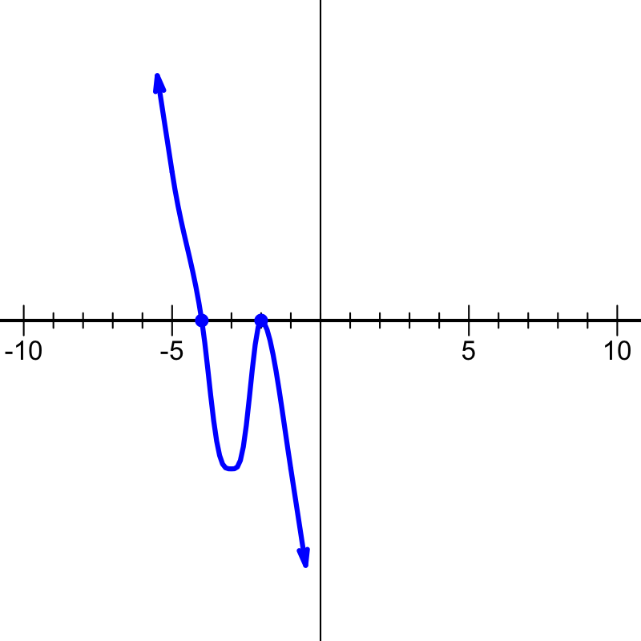

Which polynomial (in factored form) best matches the sketch?

$y=(x+4)(x+2)$$y=(x+4)(x+2)^2$$y=-(x+4)(x+2)$$y=-(x+4)(x+2)^2$

If a polynomial has a factor of $x-r$, then there will be an $x$-intercept at point $(r,0)$.

In this case, the roots (the $x$-intercepts) are at:

$$-4,\,-2$$

Thus, the factors are $x+4$ and $x+2$. Notice, the $x$-intercepts where the curve "bounces" off the $x$ axis correspond to an even multiplicity, in this case a multiplicity of 2. So, we know the curve could be represented by the function below:

$$y=a(x+4)(x+2)^2$$

where $a$ is some constant.

Lastly, we need to determine whether $a$ should be positive or negative. In this problem, either $a=1$ or $a=-1$. To determine this, look at the right side of the graph. Specifically, we are considering the [end behavior of polynomials](https://www.khanacademy.org/math/algebra2/x2ec2f6f830c9fb89:poly-graphs/x2ec2f6f830c9fb89:poly-end-behavior/a/end-behavior-of-polynomials). Notice that once $x$ is larger than $-2$, all the factors will be positive, so only $a$ will dictate whether the function on the right side is positive or negative.

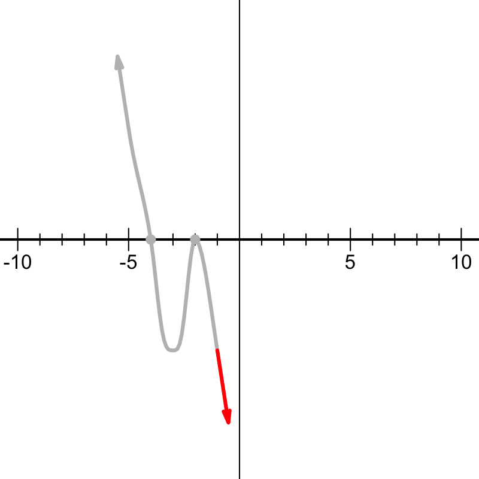

Notice, on the right side, the function is heading down. I guess more importantly, as $x\to \infty$ we see the function is negative. This implies that $a$ is negative. So, in this case, $a=-1$.

$$y=-(x+4)(x+2)^2$$

A polynomial is sketched below.

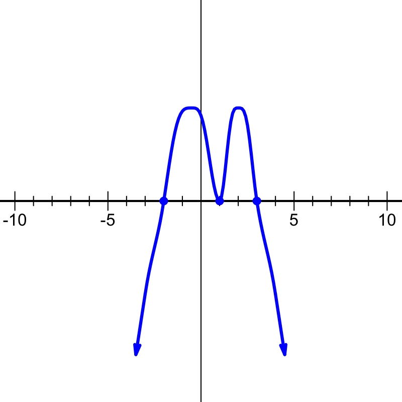

Which polynomial (in factored form) best matches the sketch?

$y=-(x-1)^2(x-3)(x+2)$$y=-(x-1)^2(x-3)^2(x+2)$$y=(x-1)^2(x-3)^2(x+2)$$y=(x-1)^2(x-3)(x+2)$

If a polynomial has a factor of $x-r$, then there will be an $x$-intercept at point $(r,0)$.

In this case, the roots (the $x$-intercepts) are at:

$$-2,\,1,\,3$$

Thus, the factors are $x+2$ and $x-1$ and $x-3$. Notice, the $x$-intercepts where the curve "bounces" off the $x$ axis correspond to an even multiplicity, in this case a multiplicity of 2. So, we know the curve could be represented by the function below:

$$y=a(x+2)(x-1)^2(x-3)$$

where $a$ is some constant.

Lastly, we need to determine whether $a$ should be positive or negative. In this problem, either $a=1$ or $a=-1$. To determine this, look at the right side of the graph. Specifically, we are considering the [end behavior of polynomials](https://www.khanacademy.org/math/algebra2/x2ec2f6f830c9fb89:poly-graphs/x2ec2f6f830c9fb89:poly-end-behavior/a/end-behavior-of-polynomials). Notice that once $x$ is larger than $3$, all the factors will be positive, so only $a$ will dictate whether the function on the right side is positive or negative.

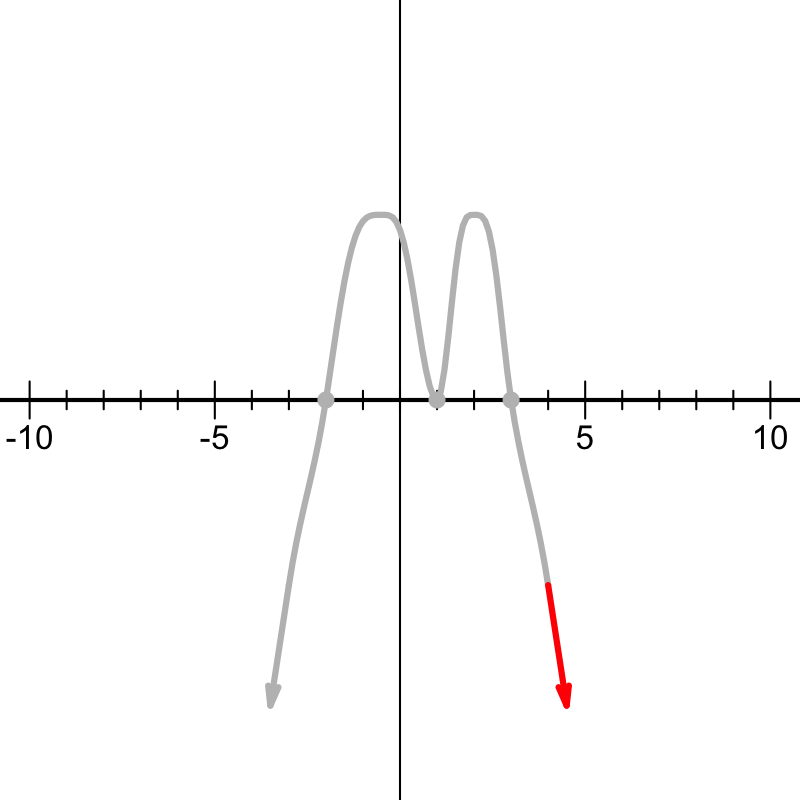

Notice, on the right side, the function is heading down. I guess more importantly, as $x\to \infty$ we see the function is negative. This implies that $a$ is negative. So, in this case, $a=-1$.

$$y=-(x+2)(x-1)^2(x-3)$$

And then, since multiplication is commutative, the factors can be written in any order. In this case, the correct answer is:

$$y=-(x-1)^2(x-3)(x+2)$$

A polynomial is sketched below.

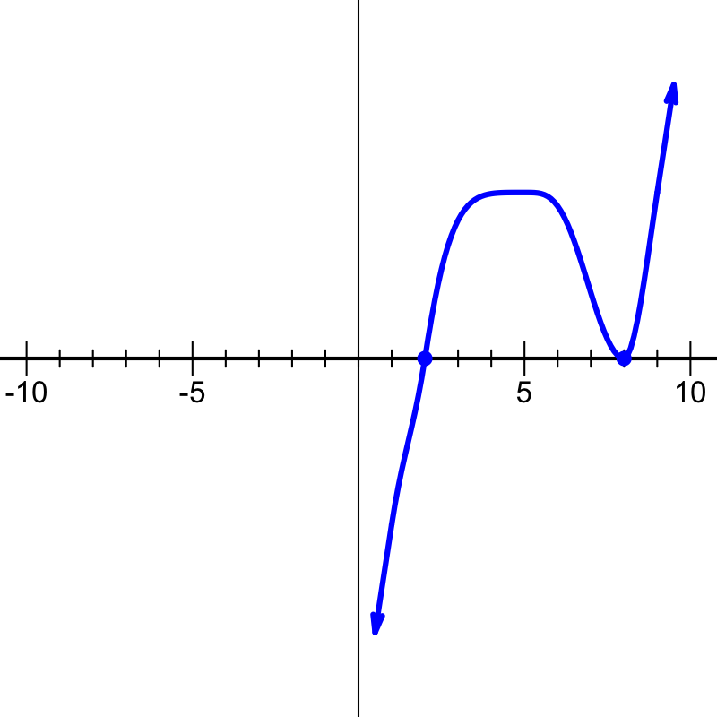

Which polynomial (in factored form) best matches the sketch?

$y=-(x-8)^2(x-2)$$y=(x-8)(x-2)$$y=(x-8)^2(x-2)$$y=-(x-8)(x-2)$

If a polynomial has a factor of $x-r$, then there will be an $x$-intercept at point $(r,0)$.

In this case, the roots (the $x$-intercepts) are at:

$$2,\,8$$

Thus, the factors are $x-2$ and $x-8$. Notice, the $x$-intercepts where the curve "bounces" off the $x$ axis correspond to an even multiplicity, in this case a multiplicity of 2. So, we know the curve could be represented by the function below:

$$y=a(x-2)(x-8)^2$$

where $a$ is some constant.

Lastly, we need to determine whether $a$ should be positive or negative. In this problem, either $a=1$ or $a=-1$. To determine this, look at the right side of the graph. Specifically, we are considering the [end behavior of polynomials](https://www.khanacademy.org/math/algebra2/x2ec2f6f830c9fb89:poly-graphs/x2ec2f6f830c9fb89:poly-end-behavior/a/end-behavior-of-polynomials). Notice that once $x$ is larger than $8$, all the factors will be positive, so only $a$ will dictate whether the function on the right side is positive or negative.

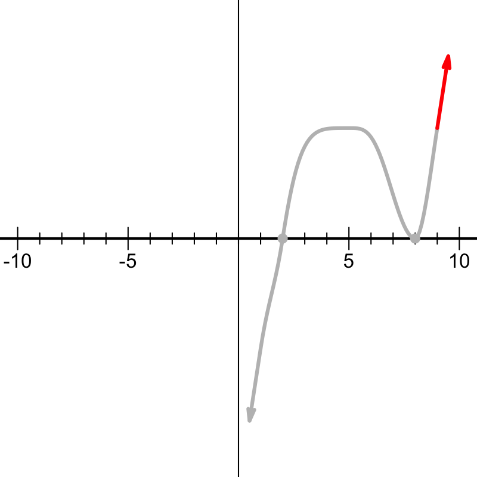

Notice, on the right side, the function is heading up. I guess more importantly, as $x\to \infty$ we see the function is positive. This implies that $a$ is positive. So, in this case, $a=1$.

$$y=(x-2)(x-8)^2$$

And then, since multiplication is commutative, the factors can be written in any order. In this case, the correct answer is:

$$y=(x-8)^2(x-2)$$

A polynomial is sketched below.

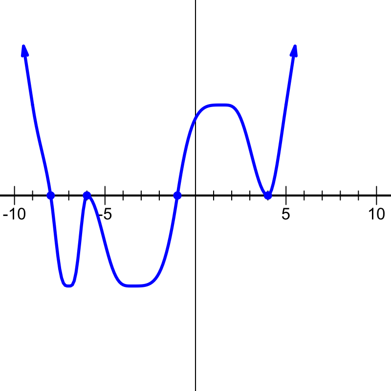

Which polynomial (in factored form) best matches the sketch?

$y=-(x-4)^2(x+1)(x+6)^2(x+8)$$y=(x-4)^2(x+1)(x+6)^2(x+8)$$y=-(x-4)^2(x+1)(x+6)(x+8)^2$$y=(x-4)^2(x+1)(x+6)(x+8)^2$

If a polynomial has a factor of $x-r$, then there will be an $x$-intercept at point $(r,0)$.

In this case, the roots (the $x$-intercepts) are at:

$$-8,\,-6,\,-1,\,4$$

Thus, the factors are $x+8$ and $x+6$ and $x+1$ and $x-4$. Notice, the $x$-intercepts where the curve "bounces" off the $x$ axis correspond to an even multiplicity, in this case a multiplicity of 2. So, we know the curve could be represented by the function below:

$$y=a(x+8)(x+6)^2(x+1)(x-4)^2$$

where $a$ is some constant.

Lastly, we need to determine whether $a$ should be positive or negative. In this problem, either $a=1$ or $a=-1$. To determine this, look at the right side of the graph. Specifically, we are considering the [end behavior of polynomials](https://www.khanacademy.org/math/algebra2/x2ec2f6f830c9fb89:poly-graphs/x2ec2f6f830c9fb89:poly-end-behavior/a/end-behavior-of-polynomials). Notice that once $x$ is larger than $4$, all the factors will be positive, so only $a$ will dictate whether the function on the right side is positive or negative.

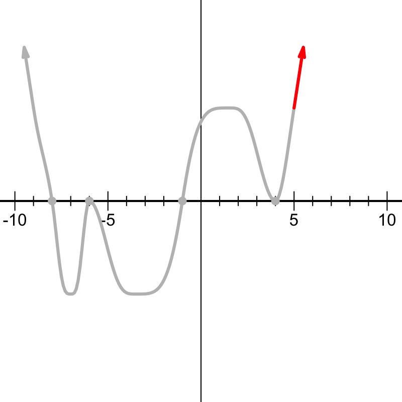

Notice, on the right side, the function is heading up. I guess more importantly, as $x\to \infty$ we see the function is positive. This implies that $a$ is positive. So, in this case, $a=1$.

$$y=(x+8)(x+6)^2(x+1)(x-4)^2$$

And then, since multiplication is commutative, the factors can be written in any order. In this case, the correct answer is:

$$y=(x-4)^2(x+1)(x+6)^2(x+8)$$

A polynomial is sketched below.

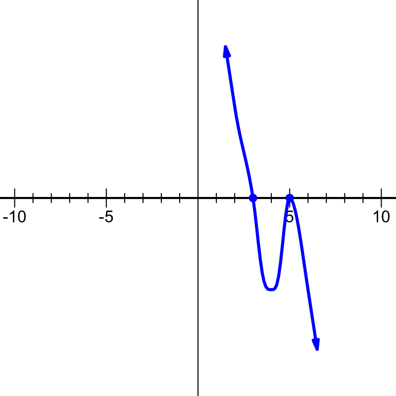

Which polynomial (in factored form) best matches the sketch?

$y=-(x-3)(x-5)^2$$y=(x-3)(x-5)^2$$y=(x-3)(x-5)$$y=-(x-3)(x-5)$

If a polynomial has a factor of $x-r$, then there will be an $x$-intercept at point $(r,0)$.

In this case, the roots (the $x$-intercepts) are at:

$$3,\,5$$

Thus, the factors are $x-3$ and $x-5$. Notice, the $x$-intercepts where the curve "bounces" off the $x$ axis correspond to an even multiplicity, in this case a multiplicity of 2. So, we know the curve could be represented by the function below:

$$y=a(x-3)(x-5)^2$$

where $a$ is some constant.

Lastly, we need to determine whether $a$ should be positive or negative. In this problem, either $a=1$ or $a=-1$. To determine this, look at the right side of the graph. Specifically, we are considering the [end behavior of polynomials](https://www.khanacademy.org/math/algebra2/x2ec2f6f830c9fb89:poly-graphs/x2ec2f6f830c9fb89:poly-end-behavior/a/end-behavior-of-polynomials). Notice that once $x$ is larger than $5$, all the factors will be positive, so only $a$ will dictate whether the function on the right side is positive or negative.

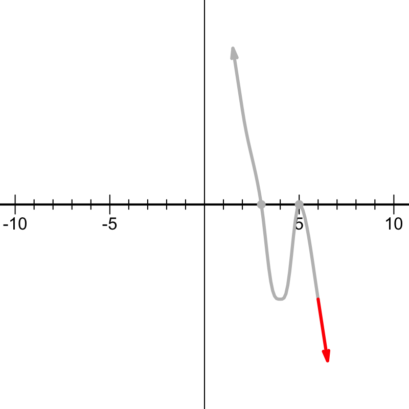

Notice, on the right side, the function is heading down. I guess more importantly, as $x\to \infty$ we see the function is negative. This implies that $a$ is negative. So, in this case, $a=-1$.

$$y=-(x-3)(x-5)^2$$

A polynomial is sketched below.

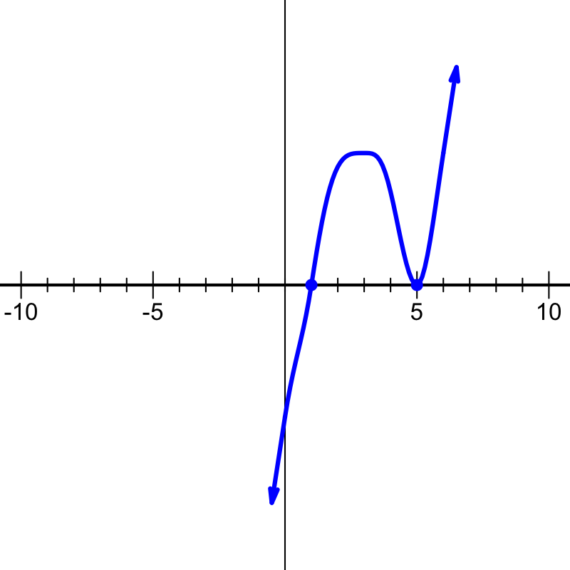

Which polynomial (in factored form) best matches the sketch?

$y=-(x-1)(x-5)^2$$y=(x-1)(x-5)^2$$y=-(x-1)^2(x-5)$$y=(x-1)^2(x-5)$

If a polynomial has a factor of $x-r$, then there will be an $x$-intercept at point $(r,0)$.

In this case, the roots (the $x$-intercepts) are at:

$$1,\,5$$

Thus, the factors are $x-1$ and $x-5$. Notice, the $x$-intercepts where the curve "bounces" off the $x$ axis correspond to an even multiplicity, in this case a multiplicity of 2. So, we know the curve could be represented by the function below:

$$y=a(x-1)(x-5)^2$$

where $a$ is some constant.

Lastly, we need to determine whether $a$ should be positive or negative. In this problem, either $a=1$ or $a=-1$. To determine this, look at the right side of the graph. Specifically, we are considering the [end behavior of polynomials](https://www.khanacademy.org/math/algebra2/x2ec2f6f830c9fb89:poly-graphs/x2ec2f6f830c9fb89:poly-end-behavior/a/end-behavior-of-polynomials). Notice that once $x$ is larger than $5$, all the factors will be positive, so only $a$ will dictate whether the function on the right side is positive or negative.

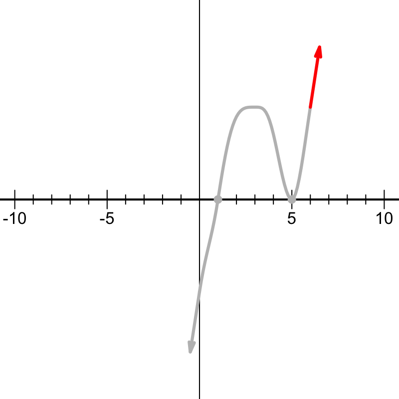

Notice, on the right side, the function is heading up. I guess more importantly, as $x\to \infty$ we see the function is positive. This implies that $a$ is positive. So, in this case, $a=1$.

$$y=(x-1)(x-5)^2$$

Let function $f$ be a polynomial with real coefficients. If $f(6+9i)=0$, then that implies that $6+9i$ is one root of the polynomial.

What is the other known root?

When a polynomial with real coefficients has a complex root, we know the [complex conjugate](https://en.wikipedia.org/wiki/Complex_conjugate) is also a root.

So, the answer is `6-9i`

Let function $f$ be a polynomial with real coefficients. If $f(-9-2i)=0$, then that implies that $-9-2i$ is one root of the polynomial.

What is the other known root?

When a polynomial with real coefficients has a complex root, we know the [complex conjugate](https://en.wikipedia.org/wiki/Complex_conjugate) is also a root.

So, the answer is `-9+2i`

Let function $f$ be a polynomial with real coefficients. If $f(7-6i)=0$, then that implies that $7-6i$ is one root of the polynomial.

What is the other known root?

When a polynomial with real coefficients has a complex root, we know the [complex conjugate](https://en.wikipedia.org/wiki/Complex_conjugate) is also a root.

So, the answer is `7+6i`

Let function $f$ be a polynomial with real coefficients. If $f(9+4i)=0$, then that implies that $9+4i$ is one root of the polynomial.

What is the other known root?

When a polynomial with real coefficients has a complex root, we know the [complex conjugate](https://en.wikipedia.org/wiki/Complex_conjugate) is also a root.

So, the answer is `9-4i`

Let function $f$ be a polynomial with real coefficients. If $f(-7+6i)=0$, then that implies that $-7+6i$ is one root of the polynomial.

What is the other known root?

When a polynomial with real coefficients has a complex root, we know the [complex conjugate](https://en.wikipedia.org/wiki/Complex_conjugate) is also a root.

So, the answer is `-7-6i`

Let function $f$ be a polynomial with real coefficients. If $f(-5-7i)=0$, then that implies that $-5-7i$ is one root of the polynomial.

What is the other known root?

When a polynomial with real coefficients has a complex root, we know the [complex conjugate](https://en.wikipedia.org/wiki/Complex_conjugate) is also a root.

So, the answer is `-5+7i`

Let $f$ represent a quartic (4th degree) polynomial with integer coefficients.

$$f(x)~=~{3}x^{4}+{28}x^{3}+{324}x^{2}+{396}x+{97}$$

One of the roots is $-4+9i$, where $i=\sqrt{-1}$.

$$f(-4+9i)~=~0$$

This quartic polynomial has at least 1 rational root. Find all the rational roots.

$-1$$-2$$-3$$-4$$-5$$-6$$-7$$-8$$-9$$\frac{-1}{2}$$\frac{-1}{3}$$\frac{-1}{4}$$\frac{-1}{5}$$\frac{-1}{6}$$\frac{-1}{7}$$\frac{-1}{8}$$\frac{-1}{9}$$\frac{-2}{3}$$\frac{-2}{5}$$\frac{-2}{7}$$\frac{-2}{9}$$\frac{-3}{2}$$\frac{-3}{4}$$\frac{-3}{5}$$\frac{-3}{7}$$\frac{-3}{8}$$\frac{-4}{3}$$\frac{-4}{5}$$\frac{-4}{7}$$\frac{-4}{9}$$\frac{-5}{2}$$\frac{-5}{3}$$\frac{-5}{4}$$\frac{-5}{6}$$\frac{-5}{7}$$\frac{-5}{8}$$\frac{-5}{9}$$\frac{-6}{5}$$\frac{-6}{7}$$\frac{-7}{2}$$\frac{-7}{3}$$\frac{-7}{4}$$\frac{-7}{5}$$\frac{-7}{6}$$\frac{-7}{8}$$\frac{-7}{9}$$\frac{-8}{3}$$\frac{-8}{5}$$\frac{-8}{7}$$\frac{-8}{9}$$\frac{-9}{2}$$\frac{-9}{4}$$\frac{-9}{5}$$\frac{-9}{7}$$\frac{1}{2}$$\frac{1}{3}$$\frac{1}{4}$$\frac{1}{5}$$\frac{1}{6}$$\frac{1}{7}$$\frac{1}{8}$$\frac{1}{9}$$\frac{2}{3}$$\frac{2}{5}$$\frac{2}{7}$$\frac{2}{9}$$\frac{3}{2}$$\frac{3}{4}$$\frac{3}{5}$$\frac{3}{7}$$\frac{3}{8}$$\frac{4}{3}$$\frac{4}{5}$$\frac{4}{7}$$\frac{4}{9}$$\frac{5}{2}$$\frac{5}{3}$$\frac{5}{4}$$\frac{5}{6}$$\frac{5}{7}$$\frac{5}{8}$$\frac{5}{9}$$\frac{6}{5}$$\frac{6}{7}$$\frac{7}{2}$$\frac{7}{3}$$\frac{7}{4}$$\frac{7}{5}$$\frac{7}{6}$$\frac{7}{8}$$\frac{7}{9}$$\frac{8}{3}$$\frac{8}{5}$$\frac{8}{7}$$\frac{8}{9}$$\frac{9}{2}$$\frac{9}{4}$$\frac{9}{5}$$\frac{9}{7}$$1$$2$$3$$4$$5$$6$$7$$8$$9$

We know that complex roots show up as complex-conjugate pairs. So, since $-4+9i$ is a root, we also know $-4-9i$ is another root. This accounts for two roots.

The [fundamental theorem of algebra](https://en.wikipedia.org/wiki/Fundamental_theorem_of_algebra) promises "every non-zero, single-variable, degree n polynomial with complex coefficients has, counted with multiplicity, exactly n complex roots."

So, we know there will be a total of 4 roots.

Thus, we should be able to express $f(x)$ in a semi-factored form (with yet to be determined coefficients $a$ and $b$ and $c$).

$$f(x)~=~(ax^2+bx+c)(x-(-4+9i))(x-(-4-9i))$$

Distribute the negatives across the inner parentheses.

$$f(x)~=~(ax^2+bx+c)(x+4-9i)(x+4+9i)$$

Now use a box to multiply the two complex factors.

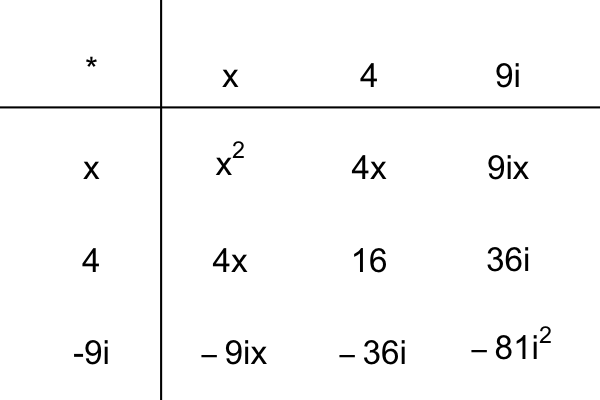

Remember, $i^2=-1$, so $-81i^2=81$. Combine like terms.

$$f(x)~=~(ax^2+bx+c)(x^2+8x+97)$$

Now... we know this semi-factored form and the standard form are equivalent expressions.

$$(ax^2+bx+c)(x^2+8x+97)~\equiv~{3}x^{4}+{28}x^{3}+{324}x^{2}+{396}x+{97}$$

So, we can divide both sides by $x^{2}+{8}x+{97}$.

$$ax^2+bx+c~=~\frac{{3}x^{4}+{28}x^{3}+{324}x^{2}+{396}x+{97}}{x^{2}+{8}x+{97}}$$

Use the box method to divide.

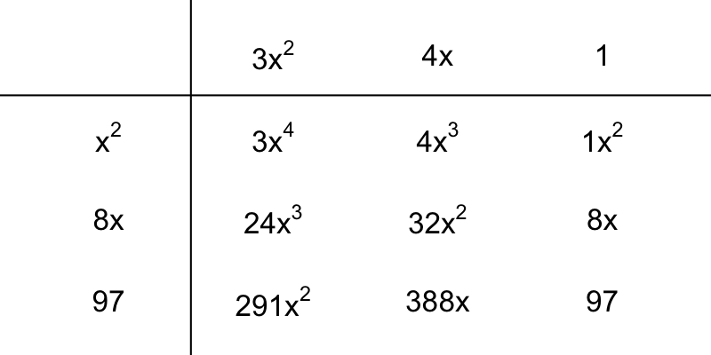

So,

$$f(x)~=~({3}x^{2}+{4}x+{1})(x^{2}+{8}x+{97})$$

We have expressed the quartic polynomial as the product of two quadratic polynomials. Remember, our goal is to find solutions to $f(x)=0$. We already know that $x=-4+9i$ and $x=-4-9i$ are solutions, and those two roots correspond to the factor $x^{2}+{8}x+{97}$ equaling 0. By setting the other quadratic factor, ${3}x^{2}+{4}x+{1}$, equal to zero, we can find the other roots.

$${3}x^{2}+{4}x+{1}=0$$

Use the quadratic formula: if $ax^2+bx+c=0$ then $x=\frac{-b\pm\sqrt{b^2-4ac}}{2a}$.

$$x=\frac{-(4)\pm\sqrt{(4)^2-4(3)(1)}}{2(3)}$$

Simplify.

$$x=\frac{-4\pm\sqrt{16-12}}{6}$$

Simplify.

$$x=\frac{-4\pm\sqrt{4}}{6}$$

Simplify.

$$x=\frac{-4\pm2}{6}$$

Split into two different fraction.

$$\begin{align}
x&=\frac{-4+2}{6} &&& x&=\frac{-4-2}{6} \\\\
x&=\frac{-2}{6} &&& x&=\frac{-6}{6} \\\\
x&=\frac{-1}{3} &&& x&=-1
\end{align}$$

Now we know all four roots. We could express $f$ in fully factored form.

$$f(x)~=~({3}x+{1})(x+{1})(x-(-4+9i))(x-(-4-9i))$$

Or, if you are not into complex factors, you could also express $f$ as factored as possible with integer coefficients.

$$f(x)~=~({3}x+{1})(x+{1})(x^{2}+{8}x+{97})$$

Anyway, the two rational roots are $\frac{-1}{3}$ and $-1$.

Let $f$ represent a quartic (4th degree) polynomial with integer coefficients.

$$f(x)~=~{3}x^{4}-{16}x^{3}+{78}x^{2}-{184}x+{119}$$

One of the roots is $1+4i$, where $i=\sqrt{-1}$.

$$f(1+4i)~=~0$$

This quartic polynomial has at least 1 rational root. Find all the rational roots.

$-1$$-2$$-3$$-4$$-5$$-6$$-7$$-8$$-9$$\frac{-1}{2}$$\frac{-1}{3}$$\frac{-1}{4}$$\frac{-1}{5}$$\frac{-1}{6}$$\frac{-1}{7}$$\frac{-1}{8}$$\frac{-1}{9}$$\frac{-2}{3}$$\frac{-2}{5}$$\frac{-2}{7}$$\frac{-2}{9}$$\frac{-3}{2}$$\frac{-3}{4}$$\frac{-3}{5}$$\frac{-3}{7}$$\frac{-3}{8}$$\frac{-4}{3}$$\frac{-4}{5}$$\frac{-4}{7}$$\frac{-4}{9}$$\frac{-5}{2}$$\frac{-5}{3}$$\frac{-5}{4}$$\frac{-5}{6}$$\frac{-5}{7}$$\frac{-5}{8}$$\frac{-5}{9}$$\frac{-6}{5}$$\frac{-6}{7}$$\frac{-7}{2}$$\frac{-7}{3}$$\frac{-7}{4}$$\frac{-7}{5}$$\frac{-7}{6}$$\frac{-7}{8}$$\frac{-7}{9}$$\frac{-8}{3}$$\frac{-8}{5}$$\frac{-8}{7}$$\frac{-8}{9}$$\frac{-9}{2}$$\frac{-9}{4}$$\frac{-9}{5}$$\frac{-9}{7}$$\frac{1}{2}$$\frac{1}{3}$$\frac{1}{4}$$\frac{1}{5}$$\frac{1}{6}$$\frac{1}{7}$$\frac{1}{8}$$\frac{1}{9}$$\frac{2}{3}$$\frac{2}{5}$$\frac{2}{7}$$\frac{2}{9}$$\frac{3}{2}$$\frac{3}{4}$$\frac{3}{5}$$\frac{3}{7}$$\frac{3}{8}$$\frac{4}{3}$$\frac{4}{5}$$\frac{4}{7}$$\frac{4}{9}$$\frac{5}{2}$$\frac{5}{3}$$\frac{5}{4}$$\frac{5}{6}$$\frac{5}{7}$$\frac{5}{8}$$\frac{5}{9}$$\frac{6}{5}$$\frac{6}{7}$$\frac{7}{2}$$\frac{7}{3}$$\frac{7}{4}$$\frac{7}{5}$$\frac{7}{6}$$\frac{7}{8}$$\frac{7}{9}$$\frac{8}{3}$$\frac{8}{5}$$\frac{8}{7}$$\frac{8}{9}$$\frac{9}{2}$$\frac{9}{4}$$\frac{9}{5}$$\frac{9}{7}$$1$$2$$3$$4$$5$$6$$7$$8$$9$

We know that complex roots show up as complex-conjugate pairs. So, since $1+4i$ is a root, we also know $1-4i$ is another root. This accounts for two roots.

The [fundamental theorem of algebra](https://en.wikipedia.org/wiki/Fundamental_theorem_of_algebra) promises "every non-zero, single-variable, degree n polynomial with complex coefficients has, counted with multiplicity, exactly n complex roots."

So, we know there will be a total of 4 roots.

Thus, we should be able to express $f(x)$ in a semi-factored form (with yet to be determined coefficients $a$ and $b$ and $c$).

$$f(x)~=~(ax^2+bx+c)(x-(1+4i))(x-(1-4i))$$

Distribute the negatives across the inner parentheses.

$$f(x)~=~(ax^2+bx+c)(x-1-4i)(x-1+4i)$$

Now use a box to multiply the two complex factors.

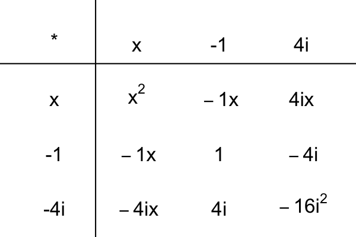

Remember, $i^2=-1$, so $-16i^2=16$. Combine like terms.

$$f(x)~=~(ax^2+bx+c)(x^2-2x+17)$$

Now... we know this semi-factored form and the standard form are equivalent expressions.

$$(ax^2+bx+c)(x^2-2x+17)~\equiv~{3}x^{4}-{16}x^{3}+{78}x^{2}-{184}x+{119}$$

So, we can divide both sides by $x^{2}-{2}x+{17}$.

$$ax^2+bx+c~=~\frac{{3}x^{4}-{16}x^{3}+{78}x^{2}-{184}x+{119}}{x^{2}-{2}x+{17}}$$

Use the box method to divide.

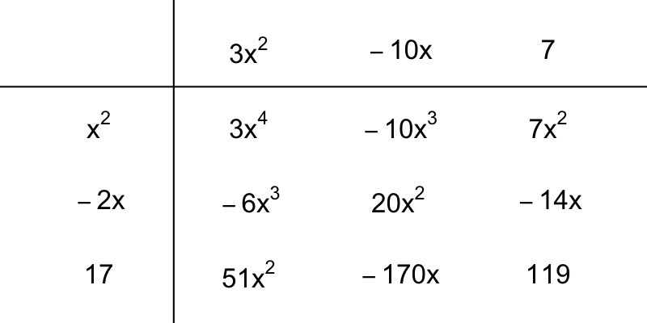

So,

$$f(x)~=~({3}x^{2}-{10}x+{7})(x^{2}-{2}x+{17})$$

We have expressed the quartic polynomial as the product of two quadratic polynomials. Remember, our goal is to find solutions to $f(x)=0$. We already know that $x=1+4i$ and $x=1-4i$ are solutions, and those two roots correspond to the factor $x^{2}-{2}x+{17}$ equaling 0. By setting the other quadratic factor, ${3}x^{2}-{10}x+{7}$, equal to zero, we can find the other roots.

$${3}x^{2}-{10}x+{7}=0$$

Use the quadratic formula: if $ax^2+bx+c=0$ then $x=\frac{-b\pm\sqrt{b^2-4ac}}{2a}$.

$$x=\frac{-(-10)\pm\sqrt{(-10)^2-4(3)(7)}}{2(3)}$$

Simplify.

$$x=\frac{10\pm\sqrt{100-84}}{6}$$

Simplify.

$$x=\frac{10\pm\sqrt{16}}{6}$$

Simplify.

$$x=\frac{10\pm4}{6}$$

Split into two different fraction.

$$\begin{align}
x&=\frac{10+4}{6} &&& x&=\frac{10-4}{6} \\\\
x&=\frac{14}{6} &&& x&=\frac{6}{6} \\\\
x&=\frac{7}{3} &&& x&=1
\end{align}$$

Now we know all four roots. We could express $f$ in fully factored form.

$$f(x)~=~(x-{1})({3}x-{7})(x-(1+4i))(x-(1-4i))$$

Or, if you are not into complex factors, you could also express $f$ as factored as possible with integer coefficients.

$$f(x)~=~(x-{1})({3}x-{7})(x^{2}-{2}x+{17})$$

Anyway, the two rational roots are $1$ and $\frac{7}{3}$.

Let $f$ represent a quartic (4th degree) polynomial with integer coefficients.

$$f(x)~=~{7}x^{4}-{81}x^{3}+{286}x^{2}-{226}x-{156}$$

One of the roots is $5-i$, where $i=\sqrt{-1}$.

$$f(5-i)~=~0$$

This quartic polynomial has at least 1 rational root. Find all the rational roots.

$-1$$-2$$-3$$-4$$-5$$-6$$-7$$-8$$-9$$\frac{-1}{2}$$\frac{-1}{3}$$\frac{-1}{4}$$\frac{-1}{5}$$\frac{-1}{6}$$\frac{-1}{7}$$\frac{-1}{8}$$\frac{-1}{9}$$\frac{-2}{3}$$\frac{-2}{5}$$\frac{-2}{7}$$\frac{-2}{9}$$\frac{-3}{2}$$\frac{-3}{4}$$\frac{-3}{5}$$\frac{-3}{7}$$\frac{-3}{8}$$\frac{-4}{3}$$\frac{-4}{5}$$\frac{-4}{7}$$\frac{-4}{9}$$\frac{-5}{2}$$\frac{-5}{3}$$\frac{-5}{4}$$\frac{-5}{6}$$\frac{-5}{7}$$\frac{-5}{8}$$\frac{-5}{9}$$\frac{-6}{5}$$\frac{-6}{7}$$\frac{-7}{2}$$\frac{-7}{3}$$\frac{-7}{4}$$\frac{-7}{5}$$\frac{-7}{6}$$\frac{-7}{8}$$\frac{-7}{9}$$\frac{-8}{3}$$\frac{-8}{5}$$\frac{-8}{7}$$\frac{-8}{9}$$\frac{-9}{2}$$\frac{-9}{4}$$\frac{-9}{5}$$\frac{-9}{7}$$\frac{1}{2}$$\frac{1}{3}$$\frac{1}{4}$$\frac{1}{5}$$\frac{1}{6}$$\frac{1}{7}$$\frac{1}{8}$$\frac{1}{9}$$\frac{2}{3}$$\frac{2}{5}$$\frac{2}{7}$$\frac{2}{9}$$\frac{3}{2}$$\frac{3}{4}$$\frac{3}{5}$$\frac{3}{7}$$\frac{3}{8}$$\frac{4}{3}$$\frac{4}{5}$$\frac{4}{7}$$\frac{4}{9}$$\frac{5}{2}$$\frac{5}{3}$$\frac{5}{4}$$\frac{5}{6}$$\frac{5}{7}$$\frac{5}{8}$$\frac{5}{9}$$\frac{6}{5}$$\frac{6}{7}$$\frac{7}{2}$$\frac{7}{3}$$\frac{7}{4}$$\frac{7}{5}$$\frac{7}{6}$$\frac{7}{8}$$\frac{7}{9}$$\frac{8}{3}$$\frac{8}{5}$$\frac{8}{7}$$\frac{8}{9}$$\frac{9}{2}$$\frac{9}{4}$$\frac{9}{5}$$\frac{9}{7}$$1$$2$$3$$4$$5$$6$$7$$8$$9$

We know that complex roots show up as complex-conjugate pairs. So, since $5-i$ is a root, we also know $5+i$ is another root. This accounts for two roots.

The [fundamental theorem of algebra](https://en.wikipedia.org/wiki/Fundamental_theorem_of_algebra) promises "every non-zero, single-variable, degree n polynomial with complex coefficients has, counted with multiplicity, exactly n complex roots."

So, we know there will be a total of 4 roots.

Thus, we should be able to express $f(x)$ in a semi-factored form (with yet to be determined coefficients $a$ and $b$ and $c$).

$$f(x)~=~(ax^2+bx+c)(x-(5-i))(x-(5+i))$$

Distribute the negatives across the inner parentheses.

$$f(x)~=~(ax^2+bx+c)(x-5+i)(x-5-i)$$

Now use a box to multiply the two complex factors.

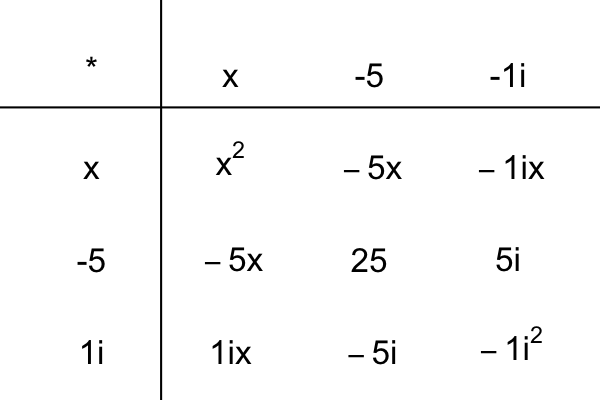

Remember, $i^2=-1$, so $-1i^2=1$. Combine like terms.

$$f(x)~=~(ax^2+bx+c)(x^2-10x+26)$$

Now... we know this semi-factored form and the standard form are equivalent expressions.

$$(ax^2+bx+c)(x^2-10x+26)~\equiv~{7}x^{4}-{81}x^{3}+{286}x^{2}-{226}x-{156}$$

So, we can divide both sides by $x^{2}-{10}x+{26}$.

$$ax^2+bx+c~=~\frac{{7}x^{4}-{81}x^{3}+{286}x^{2}-{226}x-{156}}{x^{2}-{10}x+{26}}$$

Use the box method to divide.

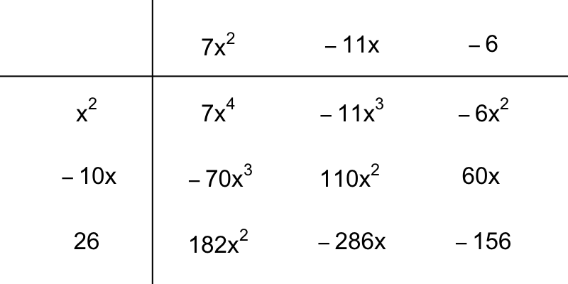

So,

$$f(x)~=~({7}x^{2}-{11}x-{6})(x^{2}-{10}x+{26})$$

We have expressed the quartic polynomial as the product of two quadratic polynomials. Remember, our goal is to find solutions to $f(x)=0$. We already know that $x=5-i$ and $x=5+i$ are solutions, and those two roots correspond to the factor $x^{2}-{10}x+{26}$ equaling 0. By setting the other quadratic factor, ${7}x^{2}-{11}x-{6}$, equal to zero, we can find the other roots.

$${7}x^{2}-{11}x-{6}=0$$

Use the quadratic formula: if $ax^2+bx+c=0$ then $x=\frac{-b\pm\sqrt{b^2-4ac}}{2a}$.

$$x=\frac{-(-11)\pm\sqrt{(-11)^2-4(7)(-6)}}{2(7)}$$

Simplify.

$$x=\frac{11\pm\sqrt{121+168}}{14}$$

Simplify.

$$x=\frac{11\pm\sqrt{289}}{14}$$

Simplify.

$$x=\frac{11\pm17}{14}$$

Split into two different fraction.

$$\begin{align}
x&=\frac{11+17}{14} &&& x&=\frac{11-17}{14} \\\\
x&=\frac{28}{14} &&& x&=\frac{-6}{14} \\\\
x&=2 &&& x&=\frac{-3}{7}
\end{align}$$

Now we know all four roots. We could express $f$ in fully factored form.

$$f(x)~=~({7}x+{3})(x-{2})(x-(5-i))(x-(5+i))$$

Or, if you are not into complex factors, you could also express $f$ as factored as possible with integer coefficients.

$$f(x)~=~({7}x+{3})(x-{2})(x^{2}-{10}x+{26})$$

Anyway, the two rational roots are $\frac{-3}{7}$ and $2$.

Let $f$ represent a quartic (4th degree) polynomial with integer coefficients.

$$f(x)~=~{15}x^{4}+{49}x^{3}+{180}x^{2}+{174}x-{80}$$

One of the roots is $-1-3i$, where $i=\sqrt{-1}$.

$$f(-1-3i)~=~0$$

This quartic polynomial has at least 1 rational root. Find all the rational roots.

$-1$$-2$$-3$$-4$$-5$$-6$$-7$$-8$$-9$$\frac{-1}{2}$$\frac{-1}{3}$$\frac{-1}{4}$$\frac{-1}{5}$$\frac{-1}{6}$$\frac{-1}{7}$$\frac{-1}{8}$$\frac{-1}{9}$$\frac{-2}{3}$$\frac{-2}{5}$$\frac{-2}{7}$$\frac{-2}{9}$$\frac{-3}{2}$$\frac{-3}{4}$$\frac{-3}{5}$$\frac{-3}{7}$$\frac{-3}{8}$$\frac{-4}{3}$$\frac{-4}{5}$$\frac{-4}{7}$$\frac{-4}{9}$$\frac{-5}{2}$$\frac{-5}{3}$$\frac{-5}{4}$$\frac{-5}{6}$$\frac{-5}{7}$$\frac{-5}{8}$$\frac{-5}{9}$$\frac{-6}{5}$$\frac{-6}{7}$$\frac{-7}{2}$$\frac{-7}{3}$$\frac{-7}{4}$$\frac{-7}{5}$$\frac{-7}{6}$$\frac{-7}{8}$$\frac{-7}{9}$$\frac{-8}{3}$$\frac{-8}{5}$$\frac{-8}{7}$$\frac{-8}{9}$$\frac{-9}{2}$$\frac{-9}{4}$$\frac{-9}{5}$$\frac{-9}{7}$$\frac{1}{2}$$\frac{1}{3}$$\frac{1}{4}$$\frac{1}{5}$$\frac{1}{6}$$\frac{1}{7}$$\frac{1}{8}$$\frac{1}{9}$$\frac{2}{3}$$\frac{2}{5}$$\frac{2}{7}$$\frac{2}{9}$$\frac{3}{2}$$\frac{3}{4}$$\frac{3}{5}$$\frac{3}{7}$$\frac{3}{8}$$\frac{4}{3}$$\frac{4}{5}$$\frac{4}{7}$$\frac{4}{9}$$\frac{5}{2}$$\frac{5}{3}$$\frac{5}{4}$$\frac{5}{6}$$\frac{5}{7}$$\frac{5}{8}$$\frac{5}{9}$$\frac{6}{5}$$\frac{6}{7}$$\frac{7}{2}$$\frac{7}{3}$$\frac{7}{4}$$\frac{7}{5}$$\frac{7}{6}$$\frac{7}{8}$$\frac{7}{9}$$\frac{8}{3}$$\frac{8}{5}$$\frac{8}{7}$$\frac{8}{9}$$\frac{9}{2}$$\frac{9}{4}$$\frac{9}{5}$$\frac{9}{7}$$1$$2$$3$$4$$5$$6$$7$$8$$9$

We know that complex roots show up as complex-conjugate pairs. So, since $-1-3i$ is a root, we also know $-1+3i$ is another root. This accounts for two roots.

The [fundamental theorem of algebra](https://en.wikipedia.org/wiki/Fundamental_theorem_of_algebra) promises "every non-zero, single-variable, degree n polynomial with complex coefficients has, counted with multiplicity, exactly n complex roots."

So, we know there will be a total of 4 roots.

Thus, we should be able to express $f(x)$ in a semi-factored form (with yet to be determined coefficients $a$ and $b$ and $c$).

$$f(x)~=~(ax^2+bx+c)(x-(-1-3i))(x-(-1+3i))$$

Distribute the negatives across the inner parentheses.

$$f(x)~=~(ax^2+bx+c)(x+1+3i)(x+1-3i)$$

Now use a box to multiply the two complex factors.

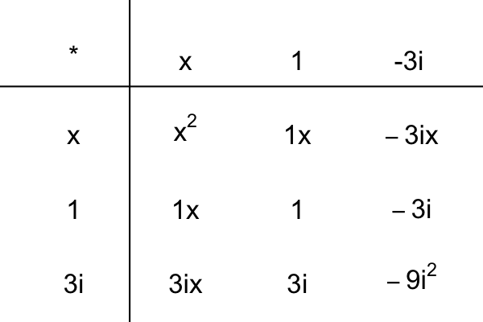

Remember, $i^2=-1$, so $-9i^2=9$. Combine like terms.

$$f(x)~=~(ax^2+bx+c)(x^2+2x+10)$$

Now... we know this semi-factored form and the standard form are equivalent expressions.

$$(ax^2+bx+c)(x^2+2x+10)~\equiv~{15}x^{4}+{49}x^{3}+{180}x^{2}+{174}x-{80}$$

So, we can divide both sides by $x^{2}+{2}x+{10}$.

$$ax^2+bx+c~=~\frac{{15}x^{4}+{49}x^{3}+{180}x^{2}+{174}x-{80}}{x^{2}+{2}x+{10}}$$

Use the box method to divide.

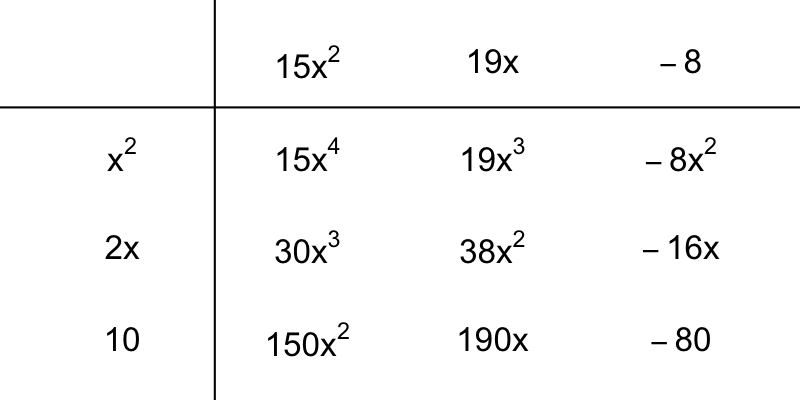

So,

$$f(x)~=~({15}x^{2}+{19}x-{8})(x^{2}+{2}x+{10})$$

We have expressed the quartic polynomial as the product of two quadratic polynomials. Remember, our goal is to find solutions to $f(x)=0$. We already know that $x=-1-3i$ and $x=-1+3i$ are solutions, and those two roots correspond to the factor $x^{2}+{2}x+{10}$ equaling 0. By setting the other quadratic factor, ${15}x^{2}+{19}x-{8}$, equal to zero, we can find the other roots.

$${15}x^{2}+{19}x-{8}=0$$

Use the quadratic formula: if $ax^2+bx+c=0$ then $x=\frac{-b\pm\sqrt{b^2-4ac}}{2a}$.

$$x=\frac{-(19)\pm\sqrt{(19)^2-4(15)(-8)}}{2(15)}$$

Simplify.

$$x=\frac{-19\pm\sqrt{361+480}}{30}$$

Simplify.

$$x=\frac{-19\pm\sqrt{841}}{30}$$

Simplify.

$$x=\frac{-19\pm29}{30}$$

Split into two different fraction.

$$\begin{align}
x&=\frac{-19+29}{30} &&& x&=\frac{-19-29}{30} \\\\
x&=\frac{10}{30} &&& x&=\frac{-48}{30} \\\\
x&=\frac{1}{3} &&& x&=\frac{-8}{5}
\end{align}$$

Now we know all four roots. We could express $f$ in fully factored form.

$$f(x)~=~({3}x-{1})({5}x+{8})(x-(-1-3i))(x-(-1+3i))$$

Or, if you are not into complex factors, you could also express $f$ as factored as possible with integer coefficients.

$$f(x)~=~({3}x-{1})({5}x+{8})(x^{2}+{2}x+{10})$$

Anyway, the two rational roots are $\frac{1}{3}$ and $\frac{-8}{5}$.

Let $f$ represent a quartic (4th degree) polynomial with integer coefficients.

$$f(x)~=~{8}x^{4}+{6}x^{3}+{109}x^{2}-{184}x-{119}$$

One of the roots is $-1-4i$, where $i=\sqrt{-1}$.

$$f(-1-4i)~=~0$$

This quartic polynomial has at least 1 rational root. Find all the rational roots.

$-1$$-2$$-3$$-4$$-5$$-6$$-7$$-8$$-9$$\frac{-1}{2}$$\frac{-1}{3}$$\frac{-1}{4}$$\frac{-1}{5}$$\frac{-1}{6}$$\frac{-1}{7}$$\frac{-1}{8}$$\frac{-1}{9}$$\frac{-2}{3}$$\frac{-2}{5}$$\frac{-2}{7}$$\frac{-2}{9}$$\frac{-3}{2}$$\frac{-3}{4}$$\frac{-3}{5}$$\frac{-3}{7}$$\frac{-3}{8}$$\frac{-4}{3}$$\frac{-4}{5}$$\frac{-4}{7}$$\frac{-4}{9}$$\frac{-5}{2}$$\frac{-5}{3}$$\frac{-5}{4}$$\frac{-5}{6}$$\frac{-5}{7}$$\frac{-5}{8}$$\frac{-5}{9}$$\frac{-6}{5}$$\frac{-6}{7}$$\frac{-7}{2}$$\frac{-7}{3}$$\frac{-7}{4}$$\frac{-7}{5}$$\frac{-7}{6}$$\frac{-7}{8}$$\frac{-7}{9}$$\frac{-8}{3}$$\frac{-8}{5}$$\frac{-8}{7}$$\frac{-8}{9}$$\frac{-9}{2}$$\frac{-9}{4}$$\frac{-9}{5}$$\frac{-9}{7}$$\frac{1}{2}$$\frac{1}{3}$$\frac{1}{4}$$\frac{1}{5}$$\frac{1}{6}$$\frac{1}{7}$$\frac{1}{8}$$\frac{1}{9}$$\frac{2}{3}$$\frac{2}{5}$$\frac{2}{7}$$\frac{2}{9}$$\frac{3}{2}$$\frac{3}{4}$$\frac{3}{5}$$\frac{3}{7}$$\frac{3}{8}$$\frac{4}{3}$$\frac{4}{5}$$\frac{4}{7}$$\frac{4}{9}$$\frac{5}{2}$$\frac{5}{3}$$\frac{5}{4}$$\frac{5}{6}$$\frac{5}{7}$$\frac{5}{8}$$\frac{5}{9}$$\frac{6}{5}$$\frac{6}{7}$$\frac{7}{2}$$\frac{7}{3}$$\frac{7}{4}$$\frac{7}{5}$$\frac{7}{6}$$\frac{7}{8}$$\frac{7}{9}$$\frac{8}{3}$$\frac{8}{5}$$\frac{8}{7}$$\frac{8}{9}$$\frac{9}{2}$$\frac{9}{4}$$\frac{9}{5}$$\frac{9}{7}$$1$$2$$3$$4$$5$$6$$7$$8$$9$

We know that complex roots show up as complex-conjugate pairs. So, since $-1-4i$ is a root, we also know $-1+4i$ is another root. This accounts for two roots.

The [fundamental theorem of algebra](https://en.wikipedia.org/wiki/Fundamental_theorem_of_algebra) promises "every non-zero, single-variable, degree n polynomial with complex coefficients has, counted with multiplicity, exactly n complex roots."

So, we know there will be a total of 4 roots.

Thus, we should be able to express $f(x)$ in a semi-factored form (with yet to be determined coefficients $a$ and $b$ and $c$).

$$f(x)~=~(ax^2+bx+c)(x-(-1-4i))(x-(-1+4i))$$

Distribute the negatives across the inner parentheses.

$$f(x)~=~(ax^2+bx+c)(x+1+4i)(x+1-4i)$$

Now use a box to multiply the two complex factors.

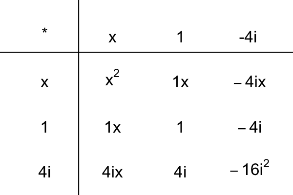

Remember, $i^2=-1$, so $-16i^2=16$. Combine like terms.

$$f(x)~=~(ax^2+bx+c)(x^2+2x+17)$$

Now... we know this semi-factored form and the standard form are equivalent expressions.

$$(ax^2+bx+c)(x^2+2x+17)~\equiv~{8}x^{4}+{6}x^{3}+{109}x^{2}-{184}x-{119}$$

So, we can divide both sides by $x^{2}+{2}x+{17}$.

$$ax^2+bx+c~=~\frac{{8}x^{4}+{6}x^{3}+{109}x^{2}-{184}x-{119}}{x^{2}+{2}x+{17}}$$

Use the box method to divide.

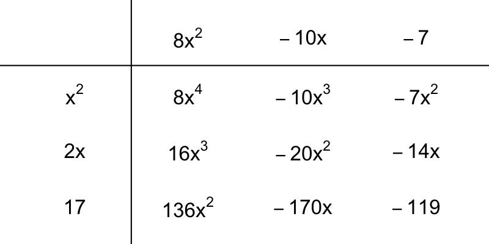

So,

$$f(x)~=~({8}x^{2}-{10}x-{7})(x^{2}+{2}x+{17})$$

We have expressed the quartic polynomial as the product of two quadratic polynomials. Remember, our goal is to find solutions to $f(x)=0$. We already know that $x=-1-4i$ and $x=-1+4i$ are solutions, and those two roots correspond to the factor $x^{2}+{2}x+{17}$ equaling 0. By setting the other quadratic factor, ${8}x^{2}-{10}x-{7}$, equal to zero, we can find the other roots.

$${8}x^{2}-{10}x-{7}=0$$

Use the quadratic formula: if $ax^2+bx+c=0$ then $x=\frac{-b\pm\sqrt{b^2-4ac}}{2a}$.

$$x=\frac{-(-10)\pm\sqrt{(-10)^2-4(8)(-7)}}{2(8)}$$

Simplify.

$$x=\frac{10\pm\sqrt{100+224}}{16}$$

Simplify.

$$x=\frac{10\pm\sqrt{324}}{16}$$

Simplify.

$$x=\frac{10\pm18}{16}$$

Split into two different fraction.

$$\begin{align}
x&=\frac{10+18}{16} &&& x&=\frac{10-18}{16} \\\\
x&=\frac{28}{16} &&& x&=\frac{-8}{16} \\\\
x&=\frac{7}{4} &&& x&=\frac{-1}{2}
\end{align}$$

Now we know all four roots. We could express $f$ in fully factored form.

$$f(x)~=~({4}x-{7})({2}x+{1})(x-(-1-4i))(x-(-1+4i))$$

Or, if you are not into complex factors, you could also express $f$ as factored as possible with integer coefficients.

$$f(x)~=~({4}x-{7})({2}x+{1})(x^{2}+{2}x+{17})$$

Anyway, the two rational roots are $\frac{7}{4}$ and $\frac{-1}{2}$.

Let $f$ represent a quartic (4th degree) polynomial with integer coefficients.

$$f(x)~=~{56}x^{4}+{79}x^{3}+{200}x^{2}-{193}x-{70}$$

One of the roots is $-1-2i$, where $i=\sqrt{-1}$.

$$f(-1-2i)~=~0$$

This quartic polynomial has at least 1 rational root. Find all the rational roots.

$-1$$-2$$-3$$-4$$-5$$-6$$-7$$-8$$-9$$\frac{-1}{2}$$\frac{-1}{3}$$\frac{-1}{4}$$\frac{-1}{5}$$\frac{-1}{6}$$\frac{-1}{7}$$\frac{-1}{8}$$\frac{-1}{9}$$\frac{-2}{3}$$\frac{-2}{5}$$\frac{-2}{7}$$\frac{-2}{9}$$\frac{-3}{2}$$\frac{-3}{4}$$\frac{-3}{5}$$\frac{-3}{7}$$\frac{-3}{8}$$\frac{-4}{3}$$\frac{-4}{5}$$\frac{-4}{7}$$\frac{-4}{9}$$\frac{-5}{2}$$\frac{-5}{3}$$\frac{-5}{4}$$\frac{-5}{6}$$\frac{-5}{7}$$\frac{-5}{8}$$\frac{-5}{9}$$\frac{-6}{5}$$\frac{-6}{7}$$\frac{-7}{2}$$\frac{-7}{3}$$\frac{-7}{4}$$\frac{-7}{5}$$\frac{-7}{6}$$\frac{-7}{8}$$\frac{-7}{9}$$\frac{-8}{3}$$\frac{-8}{5}$$\frac{-8}{7}$$\frac{-8}{9}$$\frac{-9}{2}$$\frac{-9}{4}$$\frac{-9}{5}$$\frac{-9}{7}$$\frac{1}{2}$$\frac{1}{3}$$\frac{1}{4}$$\frac{1}{5}$$\frac{1}{6}$$\frac{1}{7}$$\frac{1}{8}$$\frac{1}{9}$$\frac{2}{3}$$\frac{2}{5}$$\frac{2}{7}$$\frac{2}{9}$$\frac{3}{2}$$\frac{3}{4}$$\frac{3}{5}$$\frac{3}{7}$$\frac{3}{8}$$\frac{4}{3}$$\frac{4}{5}$$\frac{4}{7}$$\frac{4}{9}$$\frac{5}{2}$$\frac{5}{3}$$\frac{5}{4}$$\frac{5}{6}$$\frac{5}{7}$$\frac{5}{8}$$\frac{5}{9}$$\frac{6}{5}$$\frac{6}{7}$$\frac{7}{2}$$\frac{7}{3}$$\frac{7}{4}$$\frac{7}{5}$$\frac{7}{6}$$\frac{7}{8}$$\frac{7}{9}$$\frac{8}{3}$$\frac{8}{5}$$\frac{8}{7}$$\frac{8}{9}$$\frac{9}{2}$$\frac{9}{4}$$\frac{9}{5}$$\frac{9}{7}$$1$$2$$3$$4$$5$$6$$7$$8$$9$

We know that complex roots show up as complex-conjugate pairs. So, since $-1-2i$ is a root, we also know $-1+2i$ is another root. This accounts for two roots.

The [fundamental theorem of algebra](https://en.wikipedia.org/wiki/Fundamental_theorem_of_algebra) promises "every non-zero, single-variable, degree n polynomial with complex coefficients has, counted with multiplicity, exactly n complex roots."

So, we know there will be a total of 4 roots.

Thus, we should be able to express $f(x)$ in a semi-factored form (with yet to be determined coefficients $a$ and $b$ and $c$).

$$f(x)~=~(ax^2+bx+c)(x-(-1-2i))(x-(-1+2i))$$

Distribute the negatives across the inner parentheses.

$$f(x)~=~(ax^2+bx+c)(x+1+2i)(x+1-2i)$$

Now use a box to multiply the two complex factors.

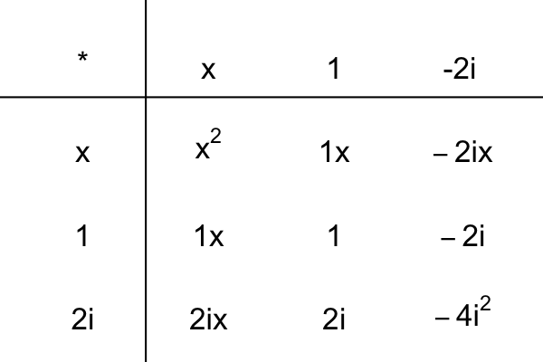

Remember, $i^2=-1$, so $-4i^2=4$. Combine like terms.

$$f(x)~=~(ax^2+bx+c)(x^2+2x+5)$$

Now... we know this semi-factored form and the standard form are equivalent expressions.

$$(ax^2+bx+c)(x^2+2x+5)~\equiv~{56}x^{4}+{79}x^{3}+{200}x^{2}-{193}x-{70}$$

So, we can divide both sides by $x^{2}+{2}x+{5}$.

$$ax^2+bx+c~=~\frac{{56}x^{4}+{79}x^{3}+{200}x^{2}-{193}x-{70}}{x^{2}+{2}x+{5}}$$

Use the box method to divide.

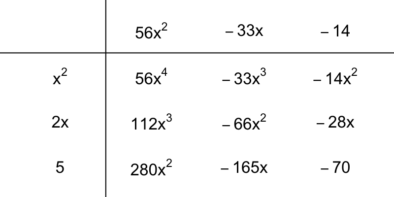

So,

$$f(x)~=~({56}x^{2}-{33}x-{14})(x^{2}+{2}x+{5})$$

We have expressed the quartic polynomial as the product of two quadratic polynomials. Remember, our goal is to find solutions to $f(x)=0$. We already know that $x=-1-2i$ and $x=-1+2i$ are solutions, and those two roots correspond to the factor $x^{2}+{2}x+{5}$ equaling 0. By setting the other quadratic factor, ${56}x^{2}-{33}x-{14}$, equal to zero, we can find the other roots.

$${56}x^{2}-{33}x-{14}=0$$

Use the quadratic formula: if $ax^2+bx+c=0$ then $x=\frac{-b\pm\sqrt{b^2-4ac}}{2a}$.

$$x=\frac{-(-33)\pm\sqrt{(-33)^2-4(56)(-14)}}{2(56)}$$

Simplify.

$$x=\frac{33\pm\sqrt{1089+3136}}{112}$$

Simplify.

$$x=\frac{33\pm\sqrt{4225}}{112}$$

Simplify.

$$x=\frac{33\pm65}{112}$$

Split into two different fraction.

$$\begin{align}
x&=\frac{33+65}{112} &&& x&=\frac{33-65}{112} \\\\
x&=\frac{98}{112} &&& x&=\frac{-32}{112} \\\\
x&=\frac{7}{8} &&& x&=\frac{-2}{7}
\end{align}$$

Now we know all four roots. We could express $f$ in fully factored form.

$$f(x)~=~({8}x-{7})({7}x+{2})(x-(-1-2i))(x-(-1+2i))$$

Or, if you are not into complex factors, you could also express $f$ as factored as possible with integer coefficients.

$$f(x)~=~({8}x-{7})({7}x+{2})(x^{2}+{2}x+{5})$$

Anyway, the two rational roots are $\frac{7}{8}$ and $\frac{-2}{7}$.